# Introduction to Artificial Neural Networks

August 21st 2019

## Why this workshop?

- The aim of this workshop is to *introduce* you to artificial neural networks in R
- The key here being *introduce*, we have limited time, so you will mainly be working with code I created
- My intention is then to leave the GitHub repo as is, so you can return and revisit and expand my code
- We will be working on instances setup by RStudio, so please go to https://rstd.io/class
- The learning objectives are (What you can expect to able to upon workshop conclusion):
  - Conceptually describe
    - What an ANN is
    - How an ANN is trained and how predictions are made
    - hyperparameters like architecture, learning rate, batch size, epochs, activation-, loss and optimizer functions
    - Training versus test partition in context of overfitting
  - Create a simple dense ANN in R using Keras
  - Evaluate the architecture and prediction performance of an ANN

## Who am I?

- My name is Leon Eyrich Jessen
- I’m from Copenhagen, Denmark
- I am an Assistant Professor at the Technical University of Denmark
- My field of research is Bioinformatics
- I was invited here, because I did a blog post for RStudio on [Deep Learning for Cancer Immunotherapy](https://blogs.rstudio.com/tensorflow/posts/2018-01-29-dl-for-cancer-immunotherapy/)

## So, what is Bioinformatics?

- Basically data science, with domain specific knowledge of biology

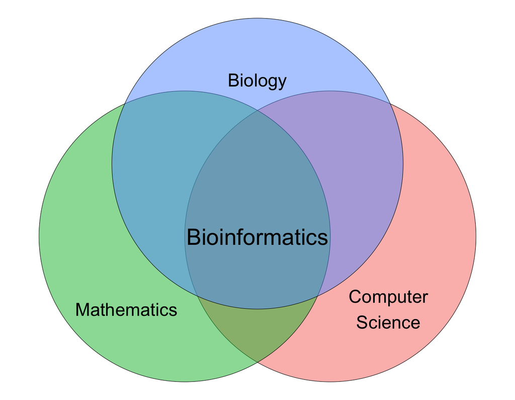

## What do I do within bioinformatics?

- I use artificial neural networks to create machine learning models of molecular interactions in the human immune system

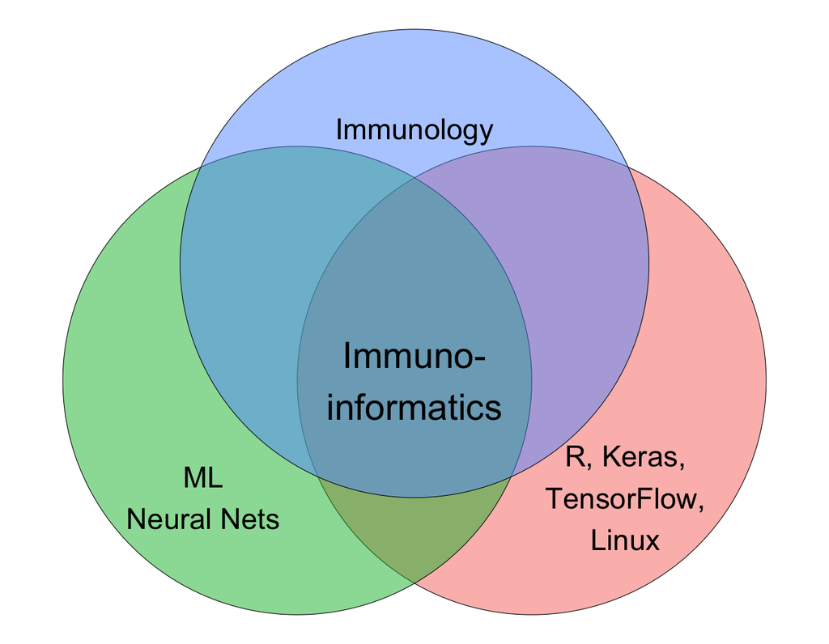

## What are Artificial Neural Networks?

- A mathematical framework for mimicking how the human brain processes data

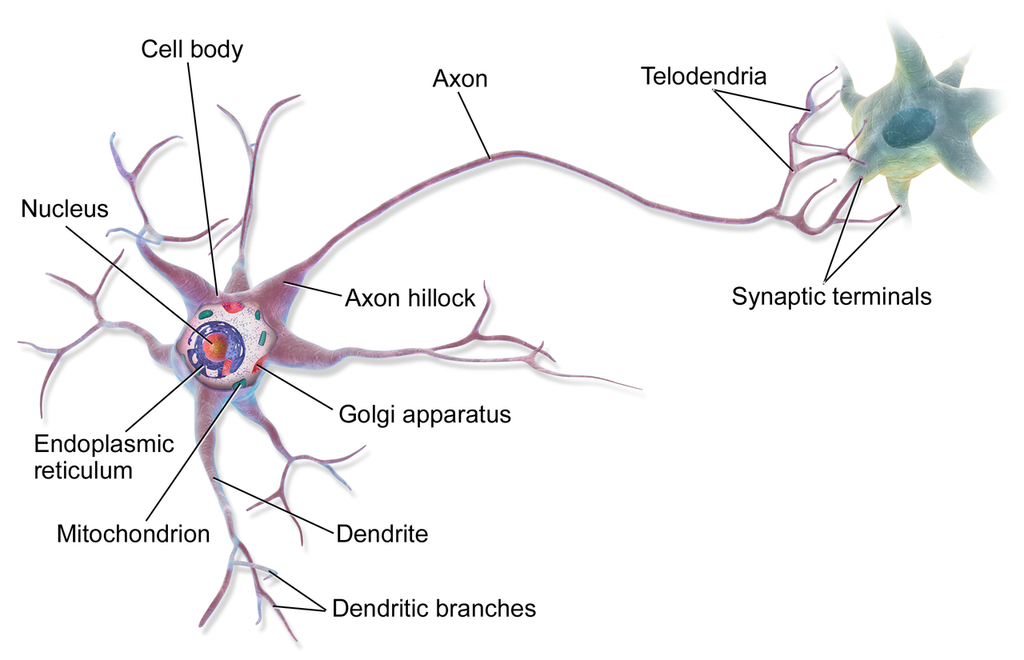

*Source: [Bruce Blaus](https://commons.wikimedia.org/wiki/User:BruceBlaus) | [Multipolar Neuron](https://upload.wikimedia.org/wikipedia/commons/1/10/Blausen_0657_MultipolarNeuron.png) | [CC BY 3.0](https://creativecommons.org/licenses/by/3.0/)*

## What are Artificial Neural Networks?

- The human brain consists of 100.000.000.000 cells
- Together they form an intrigate network
- Through hundreds of thousands of years evolution has fine tuned our brain for one purpose: Processing massive amounts of data!
- Think about it, our brain is a data center!
- Our brains processes vision, smell, taste, sound and physical touches in order for you to exist and interact with the world - All of which is happening inside you right now!
- Let’s demystify this…

## Making a Prediction: The feed forward algorithm

## Example: Fully Connected Neural Network

- To put it simple, the input vector `I` is transformed to a prediction `O`
- The input vector is simpy the set of variables in your data for a single observation
- We can visualise this like so

## Example: Fully Connected Neural Network

- `I` is the input vector, `H` is the hidden layer and `O` is the output
- `B` is the bias neuron, think intercept in the familiar \(y = b + a \cdot x\)

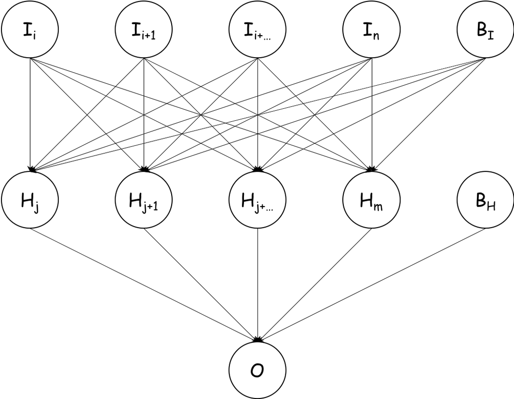

## Example: Fully Connected Neural Network

- Flow from input layer (features) to hidden layer:

  \(H_{j} = I_{i} \cdot v_{i,j} + I_{i+1} \cdot v_{i+1,j} + I_{i+...} \cdot v_{i+...,j} + I_{n} \cdot v_{n,j} + B_{I} \cdot v_{n+1,j} =\) \(\sum_{i}^{n} I_{i} \cdot v_{i,j} + B_{I} \cdot v_{n+1,j} = \sum_{i}^{n+1} I_{i} \cdot v_{i,j} = \textbf{I} \cdot \textbf{v}_j\)
- Non-linear transformation of hidden layer input to hidden layer output (activation function):

  \(S(H_{j}) = \frac{1}{1+e^{-H_{j}}}\)

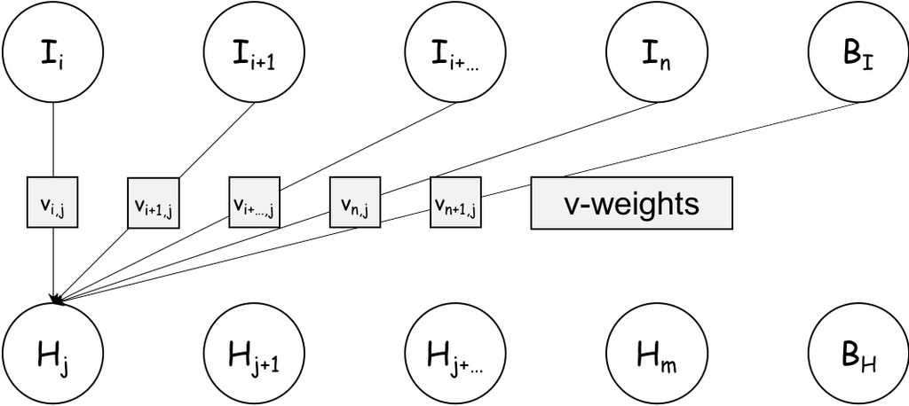

## Example: Fully Connected Neural Network

- Flow from hidden layer to output layer:

  \(O = H_{j} \cdot w_{j} + H_{j+1} \cdot w_{j+1} + H_{j+...} \cdot w_{j+...} + H_{m} \cdot w_{m} + B_{H} \cdot w_{m+1} =\) \(\sum_{j}^{m} H_{j} \cdot w_{j} + B_{H} \cdot w_{m+1} = \sum_{j}^{m+1} H_{j} \cdot w_{j} = \textbf{H} \cdot \textbf{w}\)
- Non-linear transformation of output layer input to output layer output (activation function):

  \(S(O) = \frac{1}{1+e^{-O}}\)

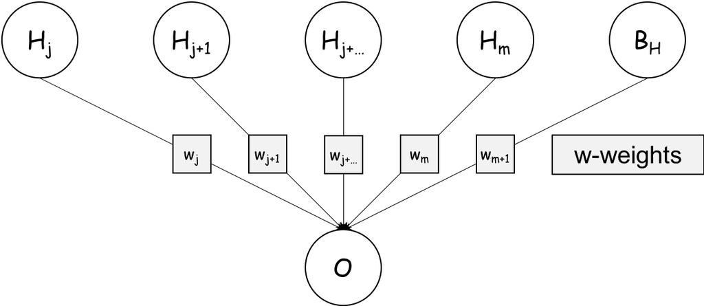

## Training a Network: The Back Propagation Algorithm

## Example: Fully Connected Neural Network

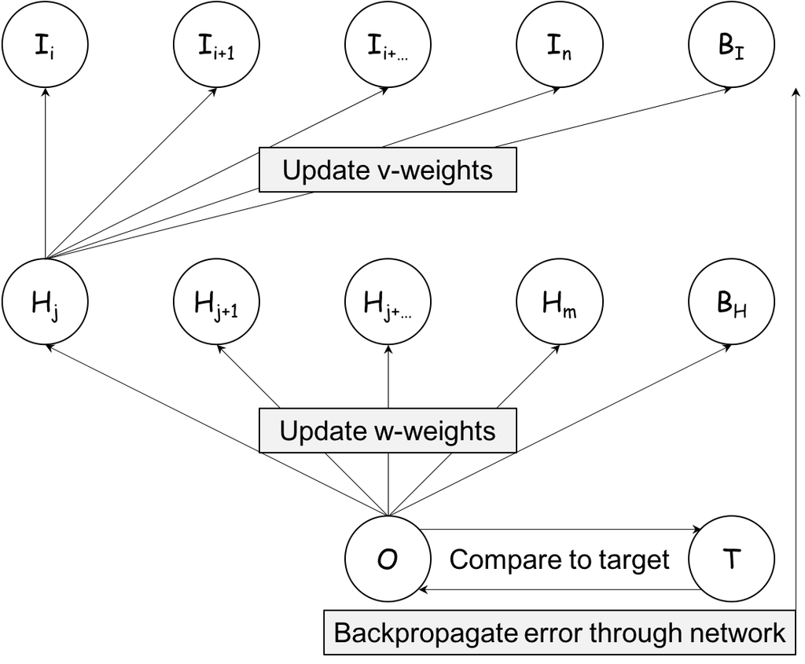

Activation function: \(S(x) = \frac{1}{1+e^{-x}}\), Loss (error) function: \(E = MSE(O,T) = \frac{1}{2} \left( o - t \right)^2\), Optimisation (weight updates) using gradient descent: \(\Delta w = - \epsilon \frac{\partial E}{\partial w}\) and \(\Delta v = - \epsilon \frac{\partial E}{\partial v}\) (\(\epsilon\) = learning rate)

## Function examples

## Activation Function - Sigmoid

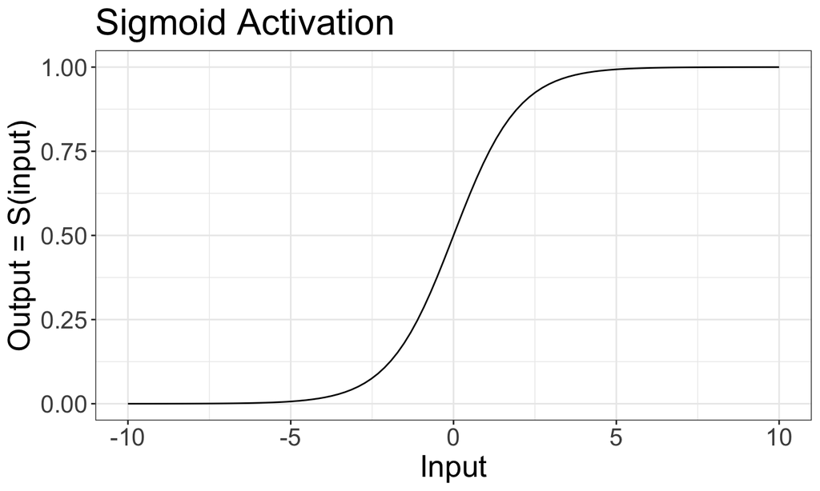

- Low input and the neuron is turned off (emits 0)
- Medium input and the neuron emits a number inbetween 0 and 1
- High input and the neuron is turned on (emits 1)

## Activation Function - Rectified Linear Unit

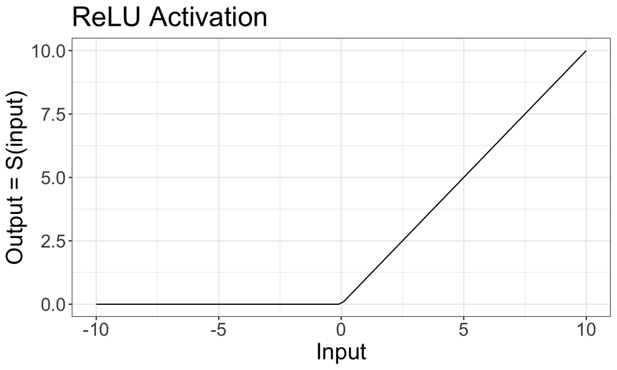

- Input less than zero and the neuron is turned off (emits 0)
- Input larger than zero and the neuron simply propagates the signal (emits x)

## Activation Function - Leaky Rectified Linear Unit

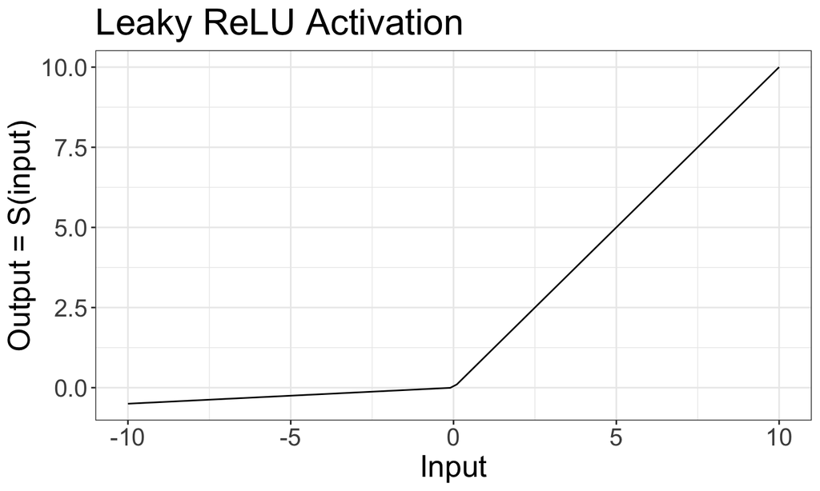

- Input less than zero and the neuron is almost turned off (emits a small number)
- Input larger than zero and the neuron simply propagates the signal (emits x)

## Activation Function - Output neuron(s)

- Choice of activation function for output neuron(s) depend on aim
  - Binary Classification: Sigmoid
  - Multiclass Classification: Softmax, softmax\((x_i) = \frac{e^{x_i}}{\sum_{i=1}^{n} e^{x_i}}\)
  - Regression: Linear

## Optimiser: Stochastic Gradient Descend

- The optimisation cannot be solved analytically, so numeric approximations are used

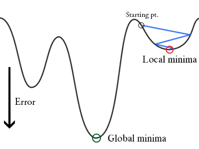

## Optimiser: Stochastic Gradient Descend

- What do you mean, it cannot be solved analytically?

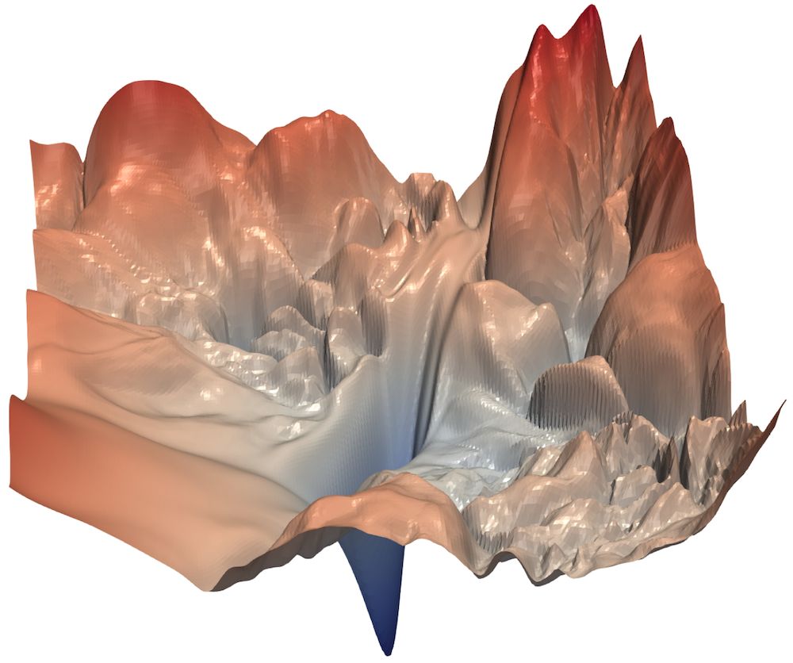

[Visualizing the Loss Landscape of Neural Nets](https://papers.nips.cc/paper/7875-visualizing-the-loss-landscape-of-neural-nets.pdf)

## Loss/error function

- Mean squared error quantifies the distance from the true value to the prediction

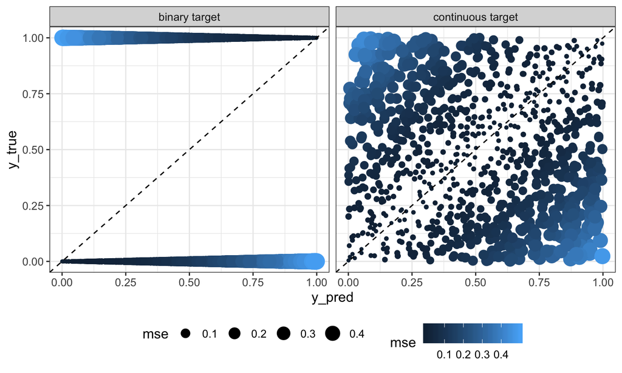

## Summary

## Key Terms and Concepts

- Features: The matrix of variables used for training th ANN
- Input layer: The first layer of neurons being fed the examples from the feature matrix
- Hidden layer(s): The layers connecting the visible input and output layers
- Output layer: The layer creating the final output (prediction)
- Feed forward algorithm: The algorithm used to make a prediction, where information flows from the input via the hidden to the output layer
- Activation function: The function used to make a non-linear transformation of the set of linear combinations feeding into a neuron
- Back propagation algorithm: The algorithm used for iteratively training the ANN
- Loss/error function: The function used to measure the error between the true and the predicted value, when training the ANN
- Optimiser: The function used for optimising the weights, when training the ANN
- Epoch: One run through all training examples
- An ANN can do both binary and multiclass classification and also regression

## Time for exercises!

- Please proceed to the exercise on prototyping an ANN
- At the exercises, I will strongly advice to pair up two-and-two, so you can discuss
- Internalising knowledge is much more effecient, when you are forced to put concepts into words